# Risk Factor Analysis

## Outcome Variable

**Outcome Variable:** whz

## Predictor Variables

**Intervention Variable:** nrooms

**Adjustment Set:**

- arm
- sex
- W_mage
- meducyrs
- feducyrs
- hhwealth_quart
- hfoodsec
- W_mhtcm
- W_nchldlt5
- W_parity
- impfloor
- impsan
- safeh20
- delta_W_mage
- delta_meducyrs
- delta_feducyrs
- delta_hhwealth_quart
- delta_hfoodsec
- delta_W_mhtcm
- delta_W_nchldlt5
- delta_W_parity
- delta_impfloor
- delta_impsan
- delta_safeh20

## Stratifying Variables

The analysis was stratified on these variable(s):

- agecat
- studyid
- country

## Data Summary

| agecat | studyid | country | nrooms | n_cell | n |
| --- | --- | --- | --- | --- | --- |
| Birth | ki0047075b-MAL-ED | BANGLADESH | 4+ | 12 | 222 |
| Birth | ki0047075b-MAL-ED | BANGLADESH | 1 | 135 | 222 |
| Birth | ki0047075b-MAL-ED | BANGLADESH | 2 | 47 | 222 |
| Birth | ki0047075b-MAL-ED | BANGLADESH | 3 | 28 | 222 |
| Birth | ki0047075b-MAL-ED | BRAZIL | 4+ | 99 | 167 |
| Birth | ki0047075b-MAL-ED | BRAZIL | 1 | 3 | 167 |
| Birth | ki0047075b-MAL-ED | BRAZIL | 2 | 19 | 167 |
| Birth | ki0047075b-MAL-ED | BRAZIL | 3 | 46 | 167 |
| Birth | ki0047075b-MAL-ED | INDIA | 4+ | 22 | 188 |
| Birth | ki0047075b-MAL-ED | INDIA | 1 | 68 | 188 |
| Birth | ki0047075b-MAL-ED | INDIA | 2 | 66 | 188 |
| Birth | ki0047075b-MAL-ED | INDIA | 3 | 32 | 188 |
| Birth | ki0047075b-MAL-ED | NEPAL | 4+ | 94 | 166 |
| Birth | ki0047075b-MAL-ED | NEPAL | 1 | 34 | 166 |
| Birth | ki0047075b-MAL-ED | NEPAL | 2 | 21 | 166 |
| Birth | ki0047075b-MAL-ED | NEPAL | 3 | 17 | 166 |
| Birth | ki0047075b-MAL-ED | PERU | 4+ | 127 | 252 |
| Birth | ki0047075b-MAL-ED | PERU | 1 | 17 | 252 |
| Birth | ki0047075b-MAL-ED | PERU | 2 | 51 | 252 |
| Birth | ki0047075b-MAL-ED | PERU | 3 | 57 | 252 |
| Birth | ki0047075b-MAL-ED | SOUTH AFRICA | 4+ | 159 | 216 |
| Birth | ki0047075b-MAL-ED | SOUTH AFRICA | 1 | 14 | 216 |
| Birth | ki0047075b-MAL-ED | SOUTH AFRICA | 2 | 20 | 216 |
| Birth | ki0047075b-MAL-ED | SOUTH AFRICA | 3 | 23 | 216 |
| Birth | ki0047075b-MAL-ED | TANZANIA, UNITED REPUBLIC OF | 4+ | 54 | 114 |
| Birth | ki0047075b-MAL-ED | TANZANIA, UNITED REPUBLIC OF | 1 | 6 | 114 |
| Birth | ki0047075b-MAL-ED | TANZANIA, UNITED REPUBLIC OF | 2 | 23 | 114 |
| Birth | ki0047075b-MAL-ED | TANZANIA, UNITED REPUBLIC OF | 3 | 31 | 114 |
| Birth | ki1000108-CMC-V-BCS-2002 | INDIA | 4+ | 5 | 88 |
| Birth | ki1000108-CMC-V-BCS-2002 | INDIA | 1 | 39 | 88 |

[output cut: 154 more lines]

The following strata were considered:

- agecat: 24 months, studyid: ki0047075b-MAL-ED, country: BANGLADESH
- agecat: 24 months, studyid: ki0047075b-MAL-ED, country: BRAZIL
- agecat: 24 months, studyid: ki0047075b-MAL-ED, country: INDIA
- agecat: 24 months, studyid: ki0047075b-MAL-ED, country: NEPAL
- agecat: 24 months, studyid: ki0047075b-MAL-ED, country: PERU
- agecat: 24 months, studyid: ki0047075b-MAL-ED, country: SOUTH AFRICA
- agecat: 24 months, studyid: ki0047075b-MAL-ED, country: TANZANIA, UNITED REPUBLIC OF
- agecat: 24 months, studyid: ki1000108-CMC-V-BCS-2002, country: INDIA
- agecat: 24 months, studyid: ki1000108-IRC, country: INDIA
- agecat: 24 months, studyid: ki1017093b-PROVIDE, country: BANGLADESH
- agecat: 24 months, studyid: ki1017093c-NIH-Crypto, country: BANGLADESH
- agecat: 24 months, studyid: ki1113344-GMS-Nepal, country: NEPAL
- agecat: 24 months, studyid: ki1114097-CONTENT, country: PERU
- agecat: 24 months, studyid: ki1135781-COHORTS, country: INDIA
- agecat: 24 months, studyid: kiGH5241-JiVitA-3, country: BANGLADESH
- agecat: 24 months, studyid: kiGH5241-JiVitA-4, country: BANGLADESH
- agecat: 6 months, studyid: ki0047075b-MAL-ED, country: BANGLADESH
- agecat: 6 months, studyid: ki0047075b-MAL-ED, country: BRAZIL
- agecat: 6 months, studyid: ki0047075b-MAL-ED, country: INDIA
- agecat: 6 months, studyid: ki0047075b-MAL-ED, country: NEPAL
- agecat: 6 months, studyid: ki0047075b-MAL-ED, country: PERU
- agecat: 6 months, studyid: ki0047075b-MAL-ED, country: SOUTH AFRICA
- agecat: 6 months, studyid: ki0047075b-MAL-ED, country: TANZANIA, UNITED REPUBLIC OF
- agecat: 6 months, studyid: ki1000108-CMC-V-BCS-2002, country: INDIA
- agecat: 6 months, studyid: ki1000108-IRC, country: INDIA
- agecat: 6 months, studyid: ki1017093b-PROVIDE, country: BANGLADESH
- agecat: 6 months, studyid: ki1017093c-NIH-Crypto, country: BANGLADESH
- agecat: 6 months, studyid: ki1113344-GMS-Nepal, country: NEPAL
- agecat: 6 months, studyid: ki1114097-CONTENT, country: PERU
- agecat: 6 months, studyid: ki1135781-COHORTS, country: INDIA
- agecat: 6 months, studyid: kiGH5241-JiVitA-3, country: BANGLADESH
- agecat: 6 months, studyid: kiGH5241-JiVitA-4, country: BANGLADESH
- agecat: Birth, studyid: ki0047075b-MAL-ED, country: BANGLADESH
- agecat: Birth, studyid: ki0047075b-MAL-ED, country: BRAZIL
- agecat: Birth, studyid: ki0047075b-MAL-ED, country: INDIA
- agecat: Birth, studyid: ki0047075b-MAL-ED, country: NEPAL
- agecat: Birth, studyid: ki0047075b-MAL-ED, country: PERU
- agecat: Birth, studyid: ki0047075b-MAL-ED, country: SOUTH AFRICA
- agecat: Birth, studyid: ki0047075b-MAL-ED, country: TANZANIA, UNITED REPUBLIC OF
- agecat: Birth, studyid: ki1000108-CMC-V-BCS-2002, country: INDIA
- agecat: Birth, studyid: ki1000108-IRC, country: INDIA
- agecat: Birth, studyid: ki1017093c-NIH-Crypto, country: BANGLADESH
- agecat: Birth, studyid: ki1114097-CONTENT, country: PERU
- agecat: Birth, studyid: ki1135781-COHORTS, country: INDIA
- agecat: Birth, studyid: kiGH5241-JiVitA-3, country: BANGLADESH
- agecat: Birth, studyid: kiGH5241-JiVitA-4, country: BANGLADESH

### Dropped Strata

Some strata were dropped due to rare outcomes:

- agecat: Birth, studyid: ki0047075b-MAL-ED, country: BRAZIL
- agecat: Birth, studyid: ki1017093c-NIH-Crypto, country: BANGLADESH
- agecat: Birth, studyid: ki1114097-CONTENT, country: PERU
- agecat: 6 months, studyid: ki0047075b-MAL-ED, country: BRAZIL
- agecat: 24 months, studyid: ki0047075b-MAL-ED, country: BRAZIL

## Methods Detail

We’re interested in the causal parameters $E[Y_a]$ for all values of $a \in \mathcal{A}$. These parameters represent the mean outcome if, possibly contrary to fact, we intervened to set all units to have $A=a$. Under the randomization and positivity assumptions, these are identified by the statistical parameters $\psi_a=E_W[E_{Y|A,W}(Y|A=a,W)]$. In addition, we’re interested in the mean of $Y$, $E[Y]$ under no intervention (the observed mean). We will estimate these parameters by using SuperLearner to fit the relevant likelihood factors – $E_{Y|A,W}(Y|A=a,W)$ and $p(A=a|W)$, and then updating our likelihood fit using a joint TMLE.

For unadjusted analyses ($W=\{\}$), initial likelihoods were estimated using Lrnr_glm to estimate the simple $E(Y|A)$ and Lrnr_mean to estimate $p(A)$. For adjusted analyses, a small library containing Lrnr_glmnet, Lrnr_xgboost, and Lrnr_mean was used.

Having estimated these parameters, we will then use the delta method to estimate relative risks and attributable risks relative to a prespecified baseline level of $A$.

# Results Detail

## Results Plots

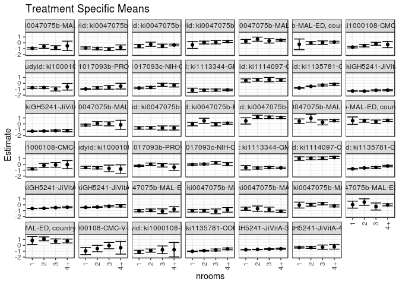

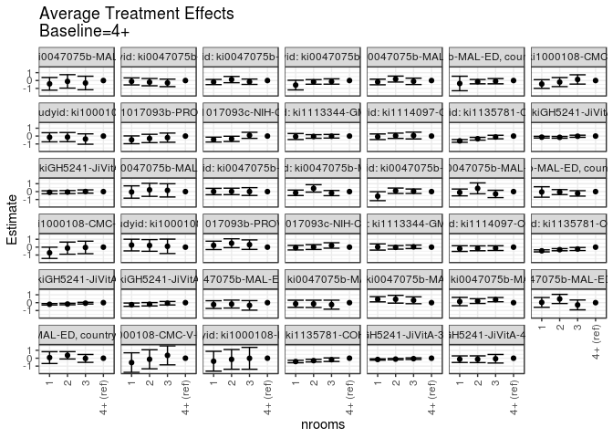

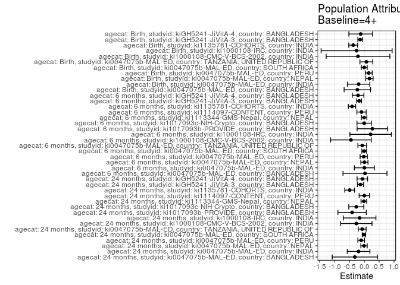

## Results Table

### Parameter: TSM

| agecat | studyid | country | intervention_level | baseline_level | estimate | ci_lower | ci_upper |
| --- | --- | --- | --- | --- | --- | --- | --- |
| Birth | ki0047075b-MAL-ED | BANGLADESH | 4+ | NA | -0.7566749 | -1.2041594 | -0.3091904 |
| Birth | ki0047075b-MAL-ED | BANGLADESH | 1 | NA | -1.0000749 | -1.2015033 | -0.7986464 |
| Birth | ki0047075b-MAL-ED | BANGLADESH | 2 | NA | -0.9345137 | -1.1571668 | -0.7118607 |
| Birth | ki0047075b-MAL-ED | BANGLADESH | 3 | NA | -1.1003205 | -1.5099543 | -0.6906868 |
| Birth | ki0047075b-MAL-ED | INDIA | 4+ | NA | -0.8629041 | -1.2565711 | -0.4692371 |
| Birth | ki0047075b-MAL-ED | INDIA | 1 | NA | -1.0061080 | -1.2338630 | -0.7783530 |
| Birth | ki0047075b-MAL-ED | INDIA | 2 | NA | -1.0118565 | -1.2531192 | -0.7705937 |
| Birth | ki0047075b-MAL-ED | INDIA | 3 | NA | -1.1166577 | -1.5244401 | -0.7088754 |
| Birth | ki0047075b-MAL-ED | NEPAL | 4+ | NA | -1.0901183 | -1.2834440 | -0.8967926 |
| Birth | ki0047075b-MAL-ED | NEPAL | 1 | NA | -0.6576814 | -0.9259457 | -0.3894171 |
| Birth | ki0047075b-MAL-ED | NEPAL | 2 | NA | -0.6554923 | -1.1041952 | -0.2067895 |
| Birth | ki0047075b-MAL-ED | NEPAL | 3 | NA | -0.7867429 | -1.1828822 | -0.3906035 |
| Birth | ki0047075b-MAL-ED | PERU | 4+ | NA | -0.1881922 | -0.3630489 | -0.0133355 |
| Birth | ki0047075b-MAL-ED | PERU | 1 | NA | -0.0452831 | -0.5459696 | 0.4554034 |
| Birth | ki0047075b-MAL-ED | PERU | 2 | NA | 0.0117298 | -0.2298680 | 0.2533275 |
| Birth | ki0047075b-MAL-ED | PERU | 3 | NA | 0.1964697 | -0.0069335 | 0.3998728 |
| Birth | ki0047075b-MAL-ED | SOUTH AFRICA | 4+ | NA | -0.0062871 | -0.1839183 | 0.1713442 |
| Birth | ki0047075b-MAL-ED | SOUTH AFRICA | 1 | NA | 0.0299238 | -0.5644696 | 0.6243172 |
| Birth | ki0047075b-MAL-ED | SOUTH AFRICA | 2 | NA | 0.4647510 | -0.0882329 | 1.0177350 |
| Birth | ki0047075b-MAL-ED | SOUTH AFRICA | 3 | NA | -0.2897913 | -0.8867866 | 0.3072040 |
| Birth | ki0047075b-MAL-ED | TANZANIA, UNITED REPUBLIC OF | 4+ | NA | 0.7324074 | 0.4023776 | 1.0624372 |
| Birth | ki0047075b-MAL-ED | TANZANIA, UNITED REPUBLIC OF | 1 | NA | 0.8100000 | 0.1361179 | 1.4838821 |
| Birth | ki0047075b-MAL-ED | TANZANIA, UNITED REPUBLIC OF | 2 | NA | 1.0960870 | 0.7670309 | 1.4251430 |
| Birth | ki0047075b-MAL-ED | TANZANIA, UNITED REPUBLIC OF | 3 | NA | 0.7051613 | 0.3277822 | 1.0825404 |
| Birth | ki1000108-CMC-V-BCS-2002 | INDIA | 4+ | NA | -0.4160000 | -1.4928519 | 0.6608519 |
| Birth | ki1000108-CMC-V-BCS-2002 | INDIA | 1 | NA | -0.9682051 | -1.5782417 | -0.3581685 |
| Birth | ki1000108-CMC-V-BCS-2002 | INDIA | 2 | NA | -0.5526923 | -1.1009266 | -0.0044580 |
| Birth | ki1000108-CMC-V-BCS-2002 | INDIA | 3 | NA | -0.0561111 | -0.5921021 | 0.4798798 |
| Birth | ki1000108-IRC | INDIA | 4+ | NA | -0.7470629 | -1.9713358 | 0.4772100 |
| Birth | ki1000108-IRC | INDIA | 1 | NA | -1.1301576 | -1.4198817 | -0.8404335 |

[output cut: 134 more lines]

### Parameter: E(Y)

| agecat | studyid | country | intervention_level | baseline_level | estimate | ci_lower | ci_upper |
| --- | --- | --- | --- | --- | --- | --- | --- |
| Birth | ki0047075b-MAL-ED | BANGLADESH | NA | NA | -0.9902252 | -1.1311070 | -0.8493435 |
| Birth | ki0047075b-MAL-ED | INDIA | NA | NA | -1.0536702 | -1.1965043 | -0.9108361 |
| Birth | ki0047075b-MAL-ED | NEPAL | NA | NA | -0.9174699 | -1.0573845 | -0.7775553 |
| Birth | ki0047075b-MAL-ED | PERU | NA | NA | -0.0384921 | -0.1542085 | 0.0772244 |
| Birth | ki0047075b-MAL-ED | SOUTH AFRICA | NA | NA | -0.0073148 | -0.1632037 | 0.1485740 |
| Birth | ki0047075b-MAL-ED | TANZANIA, UNITED REPUBLIC OF | NA | NA | 0.8024561 | 0.5990025 | 1.0059098 |
| Birth | ki1000108-CMC-V-BCS-2002 | INDIA | NA | NA | -0.6275000 | -0.9746292 | -0.2803708 |
| Birth | ki1000108-IRC | INDIA | NA | NA | -1.0053372 | -1.1922119 | -0.8184626 |
| Birth | ki1135781-COHORTS | INDIA | NA | NA | -0.9778087 | -1.0126530 | -0.9429644 |
| Birth | kiGH5241-JiVitA-3 | BANGLADESH | NA | NA | -0.7238563 | -0.7437124 | -0.7040002 |
| Birth | kiGH5241-JiVitA-4 | BANGLADESH | NA | NA | -0.3683163 | -0.4490504 | -0.2875821 |
| 6 months | ki0047075b-MAL-ED | BANGLADESH | NA | NA | -0.1354618 | -0.2647919 | -0.0061317 |
| 6 months | ki0047075b-MAL-ED | INDIA | NA | NA | -0.7056667 | -0.8312524 | -0.5800810 |
| 6 months | ki0047075b-MAL-ED | NEPAL | NA | NA | 0.1110452 | -0.0202712 | 0.2423616 |
| 6 months | ki0047075b-MAL-ED | PERU | NA | NA | 1.0527407 | 0.9299728 | 1.1755087 |
| 6 months | ki0047075b-MAL-ED | SOUTH AFRICA | NA | NA | 0.5403280 | 0.3866002 | 0.6940558 |
| 6 months | ki0047075b-MAL-ED | TANZANIA, UNITED REPUBLIC OF | NA | NA | 0.5170513 | 0.3872178 | 0.6468847 |
| 6 months | ki1000108-CMC-V-BCS-2002 | INDIA | NA | NA | -0.5026766 | -0.6536848 | -0.3516685 |
| 6 months | ki1000108-IRC | INDIA | NA | NA | -0.5900821 | -0.7252457 | -0.4549185 |
| 6 months | ki1017093b-PROVIDE | BANGLADESH | NA | NA | -0.2083706 | -0.2927992 | -0.1239419 |
| 6 months | ki1017093c-NIH-Crypto | BANGLADESH | NA | NA | 0.0297622 | -0.0491685 | 0.1086930 |
| 6 months | ki1113344-GMS-Nepal | NEPAL | NA | NA | -0.6047987 | -0.6909649 | -0.5186325 |
| 6 months | ki1114097-CONTENT | PERU | NA | NA | 1.0684318 | 0.9515274 | 1.1853362 |
| 6 months | ki1135781-COHORTS | INDIA | NA | NA | -0.7088012 | -0.7411274 | -0.6764750 |
| 6 months | kiGH5241-JiVitA-3 | BANGLADESH | NA | NA | -0.5930302 | -0.6125738 | -0.5734865 |
| 6 months | kiGH5241-JiVitA-4 | BANGLADESH | NA | NA | -0.3901595 | -0.4274150 | -0.3529041 |
| 24 months | ki0047075b-MAL-ED | BANGLADESH | NA | NA | -0.8208255 | -0.9429246 | -0.6987264 |
| 24 months | ki0047075b-MAL-ED | INDIA | NA | NA | -0.9522907 | -1.0676596 | -0.8369219 |
| 24 months | ki0047075b-MAL-ED | NEPAL | NA | NA | -0.3764474 | -0.4898516 | -0.2630431 |
| 24 months | ki0047075b-MAL-ED | PERU | NA | NA | 0.1199005 | -0.0000331 | 0.2398341 |
| 24 months | ki0047075b-MAL-ED | SOUTH AFRICA | NA | NA | 0.4267017 | 0.3074751 | 0.5459283 |
| 24 months | ki0047075b-MAL-ED | TANZANIA, UNITED REPUBLIC OF | NA | NA | 0.0500935 | -0.0748234 | 0.1750103 |
| 24 months | ki1000108-CMC-V-BCS-2002 | INDIA | NA | NA | -0.5571505 | -0.6585247 | -0.4557763 |
| 24 months | ki1000108-IRC | INDIA | NA | NA | -0.7416790 | -0.8323562 | -0.6510017 |
| 24 months | ki1017093b-PROVIDE | BANGLADESH | NA | NA | -0.8879412 | -0.9708680 | -0.8050144 |
| 24 months | ki1017093c-NIH-Crypto | BANGLADESH | NA | NA | -0.6103502 | -0.7050157 | -0.5156847 |
| 24 months | ki1113344-GMS-Nepal | NEPAL | NA | NA | -1.1315863 | -1.2192240 | -1.0439487 |
| 24 months | ki1114097-CONTENT | PERU | NA | NA | 0.5668293 | 0.4302437 | 0.7034148 |
| 24 months | ki1135781-COHORTS | INDIA | NA | NA | -0.6612799 | -0.6944511 | -0.6281088 |
| 24 months | kiGH5241-JiVitA-3 | BANGLADESH | NA | NA | -1.2967966 | -1.3200807 | -1.2735126 |
| 24 months | kiGH5241-JiVitA-4 | BANGLADESH | NA | NA | -1.2231776 | -1.2550332 | -1.1913220 |

### Parameter: ATE

| agecat | studyid | country | intervention_level | baseline_level | estimate | ci_lower | ci_upper |
| --- | --- | --- | --- | --- | --- | --- | --- |
| Birth | ki0047075b-MAL-ED | BANGLADESH | 4+ | 4+ | 0.0000000 | 0.0000000 | 0.0000000 |
| Birth | ki0047075b-MAL-ED | BANGLADESH | 1 | 4+ | -0.2434000 | -0.7346651 | 0.2478651 |
| Birth | ki0047075b-MAL-ED | BANGLADESH | 2 | 4+ | -0.1778389 | -0.6778757 | 0.3221980 |
| Birth | ki0047075b-MAL-ED | BANGLADESH | 3 | 4+ | -0.3436457 | -0.9492313 | 0.2619400 |
| Birth | ki0047075b-MAL-ED | INDIA | 4+ | 4+ | 0.0000000 | 0.0000000 | 0.0000000 |
| Birth | ki0047075b-MAL-ED | INDIA | 1 | 4+ | -0.1432039 | -0.5987801 | 0.3123722 |
| Birth | ki0047075b-MAL-ED | INDIA | 2 | 4+ | -0.1489524 | -0.6101566 | 0.3122518 |
| Birth | ki0047075b-MAL-ED | INDIA | 3 | 4+ | -0.2537537 | -0.8211756 | 0.3136683 |
| Birth | ki0047075b-MAL-ED | NEPAL | 4+ | 4+ | 0.0000000 | 0.0000000 | 0.0000000 |
| Birth | ki0047075b-MAL-ED | NEPAL | 1 | 4+ | 0.4324369 | 0.1036431 | 0.7612307 |
| Birth | ki0047075b-MAL-ED | NEPAL | 2 | 4+ | 0.4346260 | -0.0589607 | 0.9282127 |
| Birth | ki0047075b-MAL-ED | NEPAL | 3 | 4+ | 0.3033754 | -0.1344922 | 0.7412431 |
| Birth | ki0047075b-MAL-ED | PERU | 4+ | 4+ | 0.0000000 | 0.0000000 | 0.0000000 |
| Birth | ki0047075b-MAL-ED | PERU | 1 | 4+ | 0.1429091 | -0.3880149 | 0.6738331 |
| Birth | ki0047075b-MAL-ED | PERU | 2 | 4+ | 0.1999220 | -0.0990388 | 0.4988827 |
| Birth | ki0047075b-MAL-ED | PERU | 3 | 4+ | 0.3846619 | 0.1163286 | 0.6529952 |
| Birth | ki0047075b-MAL-ED | SOUTH AFRICA | 4+ | 4+ | 0.0000000 | 0.0000000 | 0.0000000 |
| Birth | ki0047075b-MAL-ED | SOUTH AFRICA | 1 | 4+ | 0.0362109 | -0.5846060 | 0.6570278 |
| Birth | ki0047075b-MAL-ED | SOUTH AFRICA | 2 | 4+ | 0.4710381 | -0.1097498 | 1.0518259 |
| Birth | ki0047075b-MAL-ED | SOUTH AFRICA | 3 | 4+ | -0.2835042 | -0.9071867 | 0.3401782 |
| Birth | ki0047075b-MAL-ED | TANZANIA, UNITED REPUBLIC OF | 4+ | 4+ | 0.0000000 | 0.0000000 | 0.0000000 |
| Birth | ki0047075b-MAL-ED | TANZANIA, UNITED REPUBLIC OF | 1 | 4+ | 0.0775926 | -0.6727651 | 0.8279503 |
| Birth | ki0047075b-MAL-ED | TANZANIA, UNITED REPUBLIC OF | 2 | 4+ | 0.3636795 | -0.1023650 | 0.8297241 |
| Birth | ki0047075b-MAL-ED | TANZANIA, UNITED REPUBLIC OF | 3 | 4+ | -0.0272461 | -0.5285790 | 0.4740867 |
| Birth | ki1000108-CMC-V-BCS-2002 | INDIA | 4+ | 4+ | 0.0000000 | 0.0000000 | 0.0000000 |
| Birth | ki1000108-CMC-V-BCS-2002 | INDIA | 1 | 4+ | -0.5522051 | -1.7898459 | 0.6854357 |
| Birth | ki1000108-CMC-V-BCS-2002 | INDIA | 2 | 4+ | -0.1366923 | -1.3450676 | 1.0716830 |
| Birth | ki1000108-CMC-V-BCS-2002 | INDIA | 3 | 4+ | 0.3598889 | -0.8429812 | 1.5627589 |
| Birth | ki1000108-IRC | INDIA | 4+ | 4+ | 0.0000000 | 0.0000000 | 0.0000000 |
| Birth | ki1000108-IRC | INDIA | 1 | 4+ | -0.3830947 | -1.6399561 | 0.8737666 |

[output cut: 134 more lines]

### Parameter: PAR

| agecat | studyid | country | intervention_level | baseline_level | estimate | ci_lower | ci_upper |
| --- | --- | --- | --- | --- | --- | --- | --- |
| Birth | ki0047075b-MAL-ED | BANGLADESH | 4+ | NA | -0.2335503 | -0.6786148 | 0.2115142 |
| Birth | ki0047075b-MAL-ED | INDIA | 4+ | NA | -0.1907661 | -0.5680236 | 0.1864913 |
| Birth | ki0047075b-MAL-ED | NEPAL | 4+ | NA | 0.1726484 | 0.0492850 | 0.2960119 |
| Birth | ki0047075b-MAL-ED | PERU | 4+ | NA | 0.1497001 | 0.0331125 | 0.2662878 |
| Birth | ki0047075b-MAL-ED | SOUTH AFRICA | 4+ | NA | -0.0010278 | -0.1000275 | 0.0979719 |
| Birth | ki0047075b-MAL-ED | TANZANIA, UNITED REPUBLIC OF | 4+ | NA | 0.0700487 | -0.1470365 | 0.2871339 |
| Birth | ki1000108-CMC-V-BCS-2002 | INDIA | 4+ | NA | -0.2115000 | -1.2831039 | 0.8601039 |
| Birth | ki1000108-IRC | INDIA | 4+ | NA | -0.2582744 | -1.4521203 | 0.9355715 |
| Birth | ki1135781-COHORTS | INDIA | 4+ | NA | -0.3735044 | -0.5227712 | -0.2242377 |
| Birth | kiGH5241-JiVitA-3 | BANGLADESH | 4+ | NA | -0.1384858 | -0.2175985 | -0.0593732 |
| Birth | kiGH5241-JiVitA-4 | BANGLADESH | 4+ | NA | -0.1210802 | -0.5199089 | 0.2777484 |
| 6 months | ki0047075b-MAL-ED | BANGLADESH | 4+ | NA | 0.0230645 | -0.7171122 | 0.7632413 |
| 6 months | ki0047075b-MAL-ED | INDIA | 4+ | NA | 0.0041070 | -0.3328681 | 0.3410822 |
| 6 months | ki0047075b-MAL-ED | NEPAL | 4+ | NA | 0.0040285 | -0.1157638 | 0.1238209 |
| 6 months | ki0047075b-MAL-ED | PERU | 4+ | NA | -0.0191554 | -0.1407985 | 0.1024876 |
| 6 months | ki0047075b-MAL-ED | SOUTH AFRICA | 4+ | NA | -0.0023500 | -0.0812010 | 0.0765010 |
| 6 months | ki0047075b-MAL-ED | TANZANIA, UNITED REPUBLIC OF | 4+ | NA | -0.0686116 | -0.2148466 | 0.0776234 |
| 6 months | ki1000108-CMC-V-BCS-2002 | INDIA | 4+ | NA | -0.4487501 | -1.1321737 | 0.2346734 |
| 6 months | ki1000108-IRC | INDIA | 4+ | NA | 0.2132712 | -0.4838535 | 0.9103959 |
| 6 months | ki1017093b-PROVIDE | BANGLADESH | 4+ | NA | 0.2727682 | -0.2412626 | 0.7867990 |
| 6 months | ki1017093c-NIH-Crypto | BANGLADESH | 4+ | NA | -0.0033672 | -0.2459457 | 0.2392113 |
| 6 months | ki1113344-GMS-Nepal | NEPAL | 4+ | NA | -0.0060510 | -0.0986664 | 0.0865643 |
| 6 months | ki1114097-CONTENT | PERU | 4+ | NA | -0.0929886 | -0.2494346 | 0.0634574 |
| 6 months | ki1135781-COHORTS | INDIA | 4+ | NA | -0.4139238 | -0.5367398 | -0.2911078 |
| 6 months | kiGH5241-JiVitA-3 | BANGLADESH | 4+ | NA | -0.1750643 | -0.2576970 | -0.0924317 |
| 6 months | kiGH5241-JiVitA-4 | BANGLADESH | 4+ | NA | -0.2093437 | -0.4043935 | -0.0142938 |
| 24 months | ki0047075b-MAL-ED | BANGLADESH | 4+ | NA | -0.3179576 | -1.0782638 | 0.4423486 |
| 24 months | ki0047075b-MAL-ED | INDIA | 4+ | NA | -0.1917851 | -0.5728566 | 0.1892863 |
| 24 months | ki0047075b-MAL-ED | NEPAL | 4+ | NA | -0.0083328 | -0.1152211 | 0.0985556 |
| 24 months | ki0047075b-MAL-ED | PERU | 4+ | NA | -0.1054381 | -0.2164500 | 0.0055737 |
| 24 months | ki0047075b-MAL-ED | SOUTH AFRICA | 4+ | NA | -0.0129040 | -0.0693131 | 0.0435051 |
| 24 months | ki0047075b-MAL-ED | TANZANIA, UNITED REPUBLIC OF | 4+ | NA | -0.0717943 | -0.2045332 | 0.0609446 |
| 24 months | ki1000108-CMC-V-BCS-2002 | INDIA | 4+ | NA | -0.2676036 | -0.7950716 | 0.2598643 |
| 24 months | ki1000108-IRC | INDIA | 4+ | NA | -0.1561863 | -0.7043750 | 0.3920024 |
| 24 months | ki1017093b-PROVIDE | BANGLADESH | 4+ | NA | -0.4095516 | -0.8868140 | 0.0677109 |
| 24 months | ki1017093c-NIH-Crypto | BANGLADESH | 4+ | NA | -0.2699000 | -0.5220300 | -0.0177699 |
| 24 months | ki1113344-GMS-Nepal | NEPAL | 4+ | NA | -0.0147038 | -0.1094423 | 0.0800346 |
| 24 months | ki1114097-CONTENT | PERU | 4+ | NA | 0.0005981 | -0.1730656 | 0.1742617 |
| 24 months | ki1135781-COHORTS | INDIA | 4+ | NA | -0.4934125 | -0.6572642 | -0.3295608 |
| 24 months | kiGH5241-JiVitA-3 | BANGLADESH | 4+ | NA | -0.1302118 | -0.2307922 | -0.0296314 |
| 24 months | kiGH5241-JiVitA-4 | BANGLADESH | 4+ | NA | -0.0663021 | -0.2430456 | 0.1104414 |